# Análisis de Datos y Machine Learning

Nombre del grupo de prácticas: GES Guillermo Carmona Martínez (1.1, portavoz), Silvia Fuentes García (1.1), Eduardo Blázquez Verdejo (1.1)

2024-12-13

```r
set.seed(1234)
credit <- read.csv("crx.data", header = FALSE, na.strings = "?")
credit_original <- read.csv("crx.data", header = FALSE, na.strings = "?")
credit.trainIdx<-readRDS("credit.trainIdx.rds")
credit.Datos.Train<-credit[credit.trainIdx,]
credit.Datos.Test<-credit[-credit.trainIdx,]
```

En esta práctica se va a abordar el estudio de un problema típico de clasificación con el objetivo de crear un modelo de clasificación efectivo mediante aprendizaje supervisado.

La base de datos utilizada en este análisis es el conjunto de datos “Credit Approval”, que contiene 16 variables y un total de 690 observaciones, siendo la última variable la clase a predecir (positiva o negativa). De las 15 variables predictoras, 6 son numéricas y 9 son categóricas.

Para llevar a cabo el análisis práctico, los datos serán divididos en dos conjuntos:

Conjunto de entrenamiento: 553 observaciones. Conjunto de prueba: 137 observaciones.

```r
summary(credit)
```

```
##       V1                  V2              V3              V4
##  Length:690         Min.   :13.75   Min.   : 0.000   Length:690
##  Class :character   1st Qu.:22.60   1st Qu.: 1.000   Class :character
##  Mode  :character   Median :28.46   Median : 2.750   Mode  :character
##                     Mean   :31.57   Mean   : 4.759
##                     3rd Qu.:38.23   3rd Qu.: 7.207
##                     Max.   :80.25   Max.   :28.000
##                     NA's   :12
##       V5                 V6                 V7                  V8
##  Length:690         Length:690         Length:690         Min.   : 0.000
##  Class :character   Class :character   Class :character   1st Qu.: 0.165
##  Mode  :character   Mode  :character   Mode  :character   Median : 1.000
##                                                           Mean   : 2.223
##                                                           3rd Qu.: 2.625
##                                                           Max.   :28.500
##
##       V9                V10                 V11           V12
##  Length:690         Length:690         Min.   : 0.0   Length:690
##  Class :character   Class :character   1st Qu.: 0.0   Class :character
##  Mode  :character   Mode  :character   Median : 0.0   Mode  :character
##                                        Mean   : 2.4
##                                        3rd Qu.: 3.0
##                                        Max.   :67.0
##
##      V13                 V14            V15               V16
##  Length:690         Min.   :   0   Min.   :     0.0   Length:690
##  Class :character   1st Qu.:  75   1st Qu.:     0.0   Class :character
##  Mode  :character   Median : 160   Median :     5.0   Mode  :character
##                     Mean   : 184   Mean   :  1017.4
##                     3rd Qu.: 276   3rd Qu.:   395.5
##                     Max.   :2000   Max.   :100000.0
##                     NA's   :13
```

Variables numéricas: V2, V3, V8, V11, V14 y V15

Variables categóricas: V1, V4, V5, V6, V7, V9, V10, V12, V13 y V16.

# Variables Categóricas

Vamos a comenzar haciendo un análisis de cada variable categórica individualmente y de cada una de ellas en relación a la variable clase

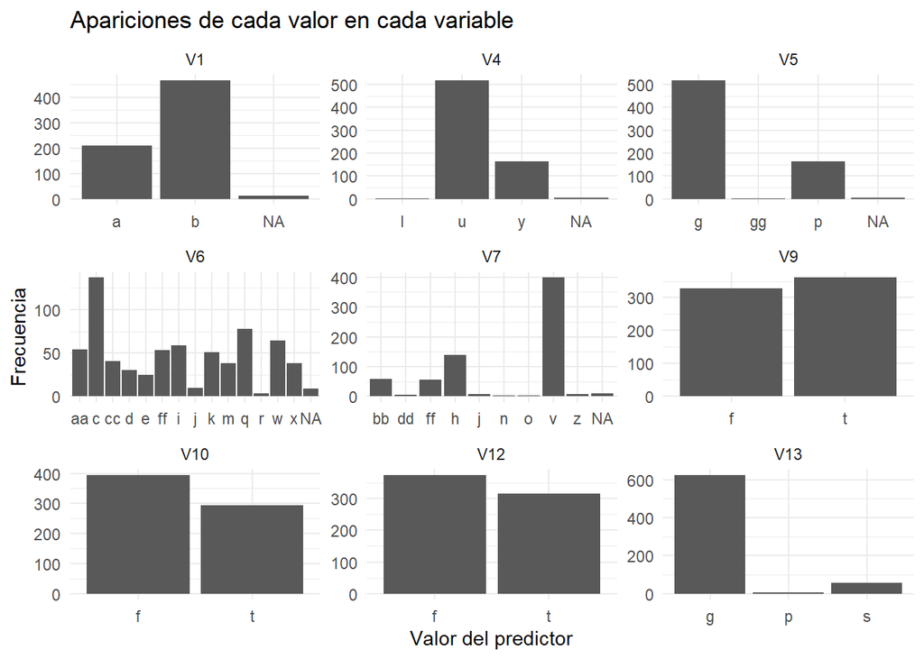

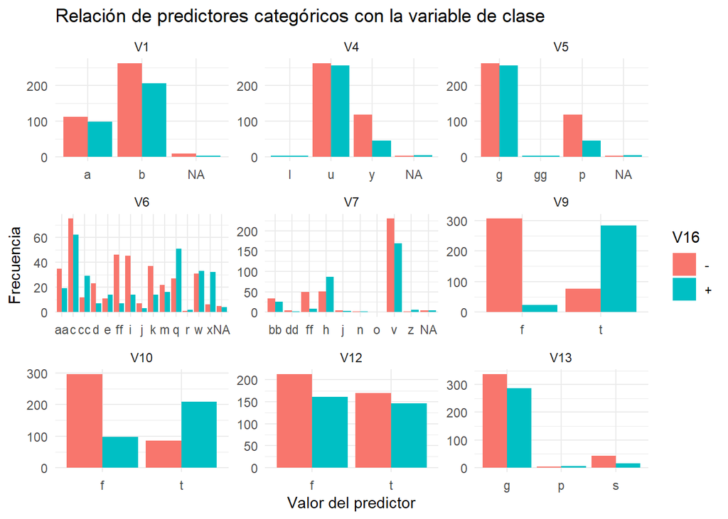

## V1

V1 se trata de un predictor categórico con valores “a” y “b”. También presenta valores nulos.

```r
V1 = credit$V1
apariciones <- table(V1, useNA = "ifany")
frecuencia <- prop.table(apariciones) * 100
cbind(apariciones, frecuencia)
```

```
##      apariciones frecuencia
## a            210   30.43478
## b            468   67.82609
## <NA>          12    1.73913
```

Como podemos ver, el valor categórico “b” aparece alrededor de 2/3 de las veces, “a” algo menos de 1/3 y hay una docena de casos nulos.

Para entender la importancia del predictor con respecto a la clase, usamos un histograma con facetas.

Se puede apreciar que existen el mismo número de casos de la categoría con valor “a” para ambos valores de clase. También hay un aumento de casos para la combinación “b” y “-”, aún así, concluimos en que no es una variable muy determinante ya que no se da un cambio de radical de distribución.

## V4

V4 se trata de un predictor categórico con valores “l”, “u” e “y”. También presenta valores nulos.

```r
V4 = credit$V4
apariciones <- table(V4, useNA = "ifany")
frecuencia <- prop.table(apariciones) * 100
cbind(apariciones, frecuencia)
```

```
##      apariciones frecuencia
## l              2  0.2898551
## u            519 75.2173913
## y            163 23.6231884
## <NA>           6  0.8695652
```

El valor “l” casi no aparece, “u” es valor predominante e “y” aparece algo menos de 1/4 de las veces. También hay 6 casos nulos.

Usamos su histograma con facetas para cuantificar la importancia de la variable con respecto a la clase.

Ambos histogramas tienen una forma pareciada, destacando que “y” pierde la mitad de los casos según la clase. No parece ser un predictor muy importante.

## V5

```r
V5 = credit$V5
apariciones <- table(V5, useNA = "ifany")
frecuencia <- prop.table(apariciones) * 100
cbind(apariciones, frecuencia)
```

```
##      apariciones frecuencia
## g            519 75.2173913
## gg             2  0.2898551
## p            163 23.6231884
## <NA>           6  0.8695652
```

- “g”: Es la categoría más frecuente en ambas clases, con frecuencias muy similares, no parece diferenciarse mucho entre clases.
- “p”: En este caso hay una diferencia notable donde la clase más frecuente es “-”
- “gg” y los valores NA son muy poco frecuentes

## V6

V6 se trata de un predictor categórico que presenta valores nulos.

```r
V6 = credit$V6
apariciones <- table(V6, useNA = "ifany")
frecuencia <- prop.table(apariciones) * 100
cbind(apariciones, frecuencia)
```

```
##      apariciones frecuencia
## aa            54  7.8260870
## c            137 19.8550725
## cc            41  5.9420290
## d             30  4.3478261
## e             25  3.6231884
## ff            53  7.6811594
## i             59  8.5507246
## j             10  1.4492754
## k             51  7.3913043
## m             38  5.5072464
## q             78 11.3043478
## r              3  0.4347826
## w             64  9.2753623
## x             38  5.5072464
## <NA>           9  1.3043478
```

Como se observa, el valor categórico más frecuente en la variable V6 es “c”, con un total de 137 apariciones, mientras que valores como “r” aparecen tan solo 3 veces, lo que evidencia una distribución desbalanceada en esta variable. Además, la variable contiene 9 casos nulos.

Para evaluar la importancia de V6 respecto a la clase objetivo, analizamos su distribución mediante un histograma con facetas. Las distribuciones para las clases “+” y “-” muestran variaciones significativas. Por ejemplo:

-Valores como “aa”, “c”, y “i” son más frecuentes en la clase “-”. -Otros valores tienen una mayor representación en la clase “+”, lo que sugiere que V6 podría estar asociada con la variable de clase.

Este análisis preliminar indica que V6 tiene el potencial de ser un predictor relevante, ya que muestra patrones específicos en su relación con las clases objetivo.

## V7

```r
V7 = credit$V7
apariciones <- table(V7, useNA = "ifany")
frecuencia <- prop.table(apariciones) * 100
cbind(apariciones, frecuencia)
```

[output not shown]

- La categoría “v” es la dominante, especialmente en la clase “-”.
- Para “ff” y “h”, podemos observar que hay también gran diferencia entre las clases.
- Las demás categorías tienen muy poca frecuencia y valores de clase similares.

## V9

V9 se trata de un predictor categórico con valores “f” y “t”. No presenta valores nulos.

```r
V9 = credit$V9
apariciones <- table(V9, useNA = "ifany")
frecuencia <- prop.table(apariciones) * 100
cbind(apariciones, frecuencia)
```

```
##   apariciones frecuencia
## f         329   47.68116
## t         361   52.31884
```

La frecuencia de ambos valores es casi igual, cerca del 50/50.

Con su histograma con facetas, es evidente la diferencia de ambos histogramas, por un lado tenemos que cuando se trata de ejemplos con la clase “-”, las ocurrencias del valor “f” son mucho mayores que las de “t” y viceversa con las de la clase “+”.

Esta variable puede ser de verdadera importancia.

## V10

V10 se trata de un predictor categórico.

```r
V10 = credit$V10
apariciones <- table(V10, useNA = "ifany")
frecuencia <- prop.table(apariciones) * 100
cbind(apariciones, frecuencia)
```

```
##   apariciones frecuencia
## f         395   57.24638
## t         295   42.75362
```

Como podemos observar, el valor “f” es la más frecuente en la variable V10, con un total de 395 apariciones, lo que representa aproximadamente el 57.25% del total. Por otro lado, el valor “t” aparece 295 veces, equivalente al 42.75%. Esto muestra que la variable está moderadamente desbalanceada en términos de frecuencias.

## V12

V12 se trata de un predictor categórico.

```r
V12 = credit$V12
apariciones <- table(V12, useNA = "ifany")
frecuencia <- prop.table(apariciones) * 100
cbind(apariciones, frecuencia)
```

```
##   apariciones frecuencia
## f         374    54.2029
## t         316    45.7971
```

La variable V12 presenta dos valores principales: f y t. el valor “f” representando aproximadamente el 54.20% del total, mientras que “t” representa el 45.80%. Aunque la diferencia entre ambos valores no es extremadamente grande, existe cierto desbalance en las frecuencias.

En cuanto a la relación con la clase objetivo:

Al igual que en la variable V10, el valor f es más prevalente en la clase “-”, lo que indica una asociación más fuerte con esta clase. Por otro lado, el valor t tiene una distribución más equilibrada entre las clases + y -.

## V13

```r
V13 = credit$V13
apariciones <- table(V13, useNA = "ifany")
frecuencia <- prop.table(apariciones) * 100
cbind(apariciones, frecuencia)
```

```
##   apariciones frecuencia
## g         625   90.57971
## p           8    1.15942
## s          57    8.26087
```

Aunque “g” es dominante y casi uniforme entre clases, “s” muestra una asociación más clara con “-”. Y “p” tiene muy pocas apariciones.

# Variables Numéricas

Seguimos haciendo un análisis de cada variable numérica individualmente y de cada una de ellas en relación a la variable clase

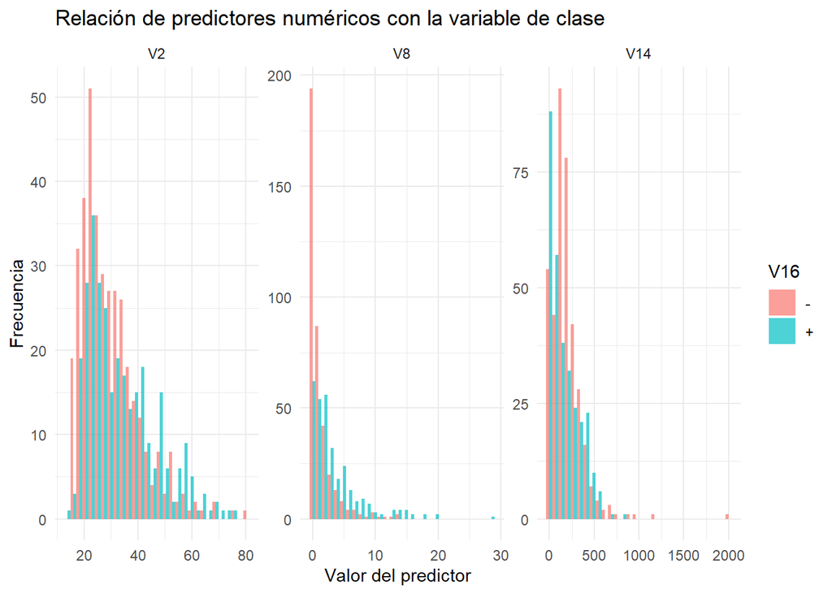

## V2

V2 es un predictor numérico de tipo float.

```r
V2 = credit$V2
summary(V2)
```

```
##    Min. 1st Qu.  Median    Mean 3rd Qu.    Max.    NA's
##   13.75   22.60   28.46   31.57   38.23   80.25      12
```

A primera vista, parece ser que el 75% de los valores están entre 13,75 y 38.23, por lo que puede haber valores fuera de rango. Otro indicador es que la media supera a la mediana.

En su histograma, vemos como existen valores extremos a partir de 60 que están afectando a la media como veíamos con los cuartiles. Aún con esto, podemos deducir que sigue una distribución normal sesgada hacia la derecha

En cuanto a su relación con la clase, hay que comprobar si tiene un comportamiento distinto la distribución de la probabilidad de la variable según la clase.

## V8

V8 es un predictor numérico de tipo float.

```r
V8 = credit$V8
summary(V8)
```

```
##    Min. 1st Qu.  Median    Mean 3rd Qu.    Max.
##   0.000   0.165   1.000   2.223   2.625  28.500
```

A primera vista, los valores parecen concentrarse principalmente entre 0.165 y 2.625 (dentro del 75% de los datos), con un valor máximo extremo de 28.5, lo que indica la presencia de posibles valores atípicos que están afectando a la media y provocando que sea mayor que la mediana. Esto sugiere una distribución sesgada a la derecha.

Al observar el histograma segmentado por clase:

Se puede notar que los valores pequeños (especialmente cerca de 0 y 1) son predominantes para ambas clases. Sin embargo, la clase - muestra mayor densidad para valores bajos de V8, mientras que la clase + tiene una representación ligeramente mayor en valores moderados. Esto indica que podría haber una leve relación entre V8 y la clase objetivo, aunque no parece ser un predictor extremadamente fuerte.

## V14

V14 es un predictor numérico de tipo float.

```r
V14 = credit$V14
summary(V14)
```

```
##    Min. 1st Qu.  Median    Mean 3rd Qu.    Max.    NA's
##       0      75     160     184     276    2000      13
```

La mediana está más cerca del primer cuartil que del tercer cuartil y la media es mayor que la mediana, lo que refuerza, como se puede observar también en el histograma que hay una distribución sesgada hacia los valores altos y asimetría positiva.

La distribución de V14 entre clases difiere. En los valores más altos se puede observar que solo tiene representación la clase negativa (-). V14 parece tener un poder discriminativo moderado para la clasificación.

## Análisis monovariable de 3 predictores

Para los siguientes predictores numéricos que hemos considerado los más interesantes, vamos a realizar un análisis monovariable

## V3

V3 es un predictor numérico de tipo float.

```r
V3 = credit$V3
summary(V3)
```

```
##    Min. 1st Qu.  Median    Mean 3rd Qu.    Max.
##   0.000   1.000   2.750   4.759   7.207  28.000
```

A primera vista, parece ser que el 75% de los valores están entre 0 y 7, por lo que se parece a la variable anterior en que puede haber valores fuera de rango y que la media supera a la mediana.

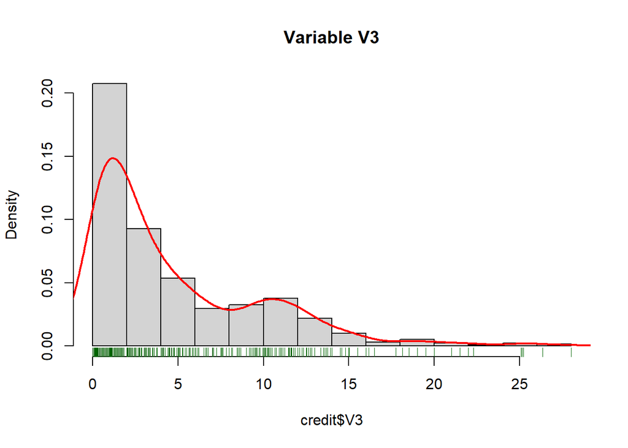

Con este histograma enriquecido se aprecia como la distribución es una normal sesgada hacia la derecha, pero en mayor proporción que la primera. Gracias al jitter podemos ver los valores extremos que podrían ser outliers. ´ En cuanto a su relación con la clase, vamos a ver si tiene un comportamiento distinto la distribución de la probabilidad de la variable según la clase.

Más allá, veremos un diagrama Q-Q donde cada punto (x,y) hace referencia a un percentil concreto del 0 al 100 y tenemos una distribución teórica normal.

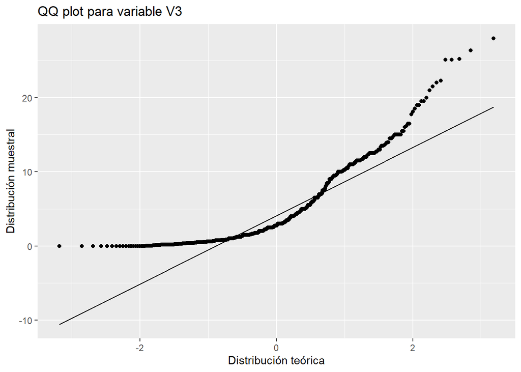

Podemos detectar los valores fuera de rango con un diagrama de caja.

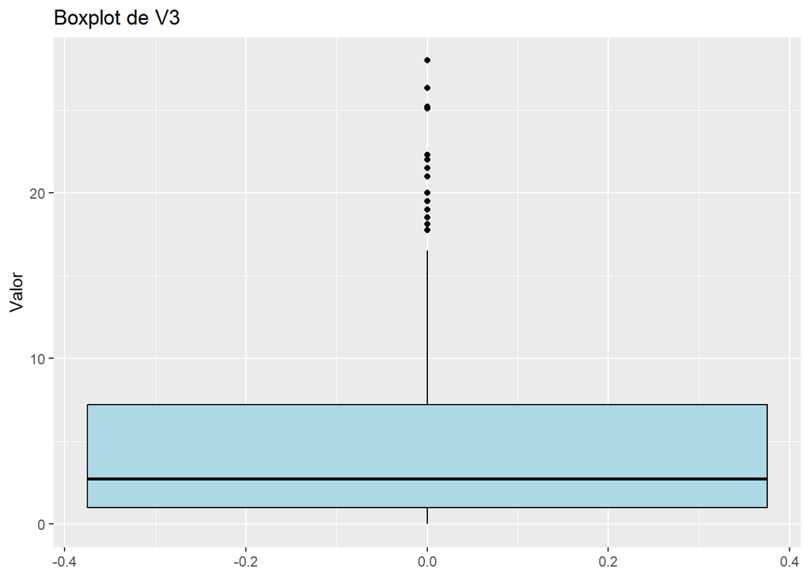

Si queremos usar más adelante técnicas como reducción de dimensionalidad basada en PCA, debemos saber que estos outliers pueden causar un detrimento en la efectividad de la técnica.

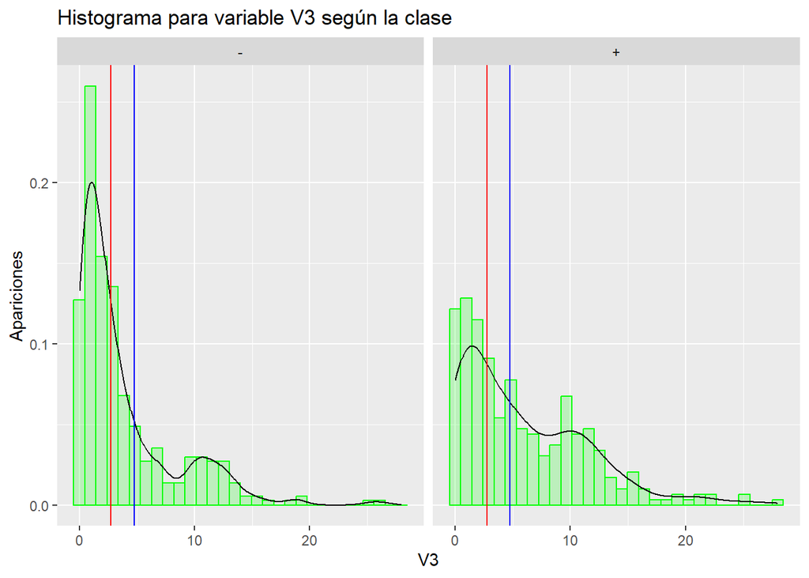

En esta gráfica vemos como dependiendo de la clase, un histograma tiene la densidad de probabilidad más pronunciada, es decir, que los valores están más agrupados que en el otro histograma. Esta variable podría ser relevante.

## V11

V11 es un predictor numérico de tipo float.

```r
V11 = credit$V11
summary(V11)
```

```
##    Min. 1st Qu.  Median    Mean 3rd Qu.    Max.
##     0.0     0.0     0.0     2.4     3.0    67.0
```

La mayoría de los valores de V11 están concentrados cerca de 0, ya que tanto el mínimo, el primer cuartil, y la mediana son 0.0.

El 75% de los datos tienen un valor menor o igual a 3.0 (según el tercer cuartil).

Existe un valor máximo de 67.0, lo cual es significativamente mayor que el resto de los valores y podría ser un valor extremo o outlier que merece más atención.

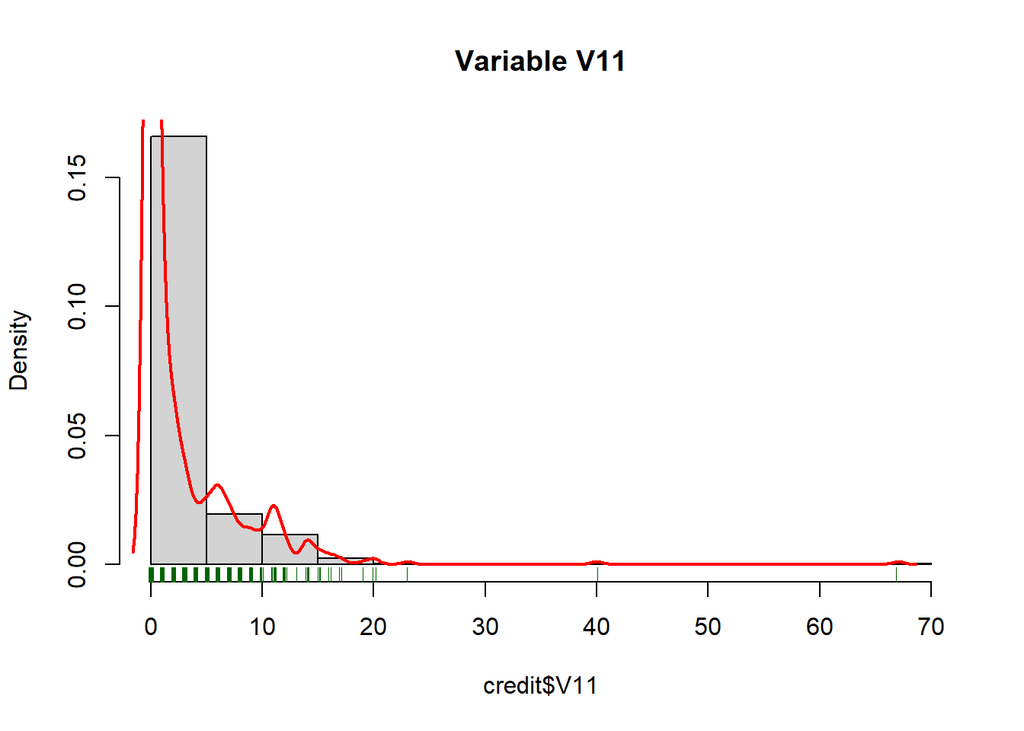

La distribución de V11 es altamente asimétrica hacia la derecha (sesgo positivo). Esto se evidencia por un pico pronunciado cerca de 0 y una larga cola que se extiende hacia valores más altos.

La curva de densidad (línea roja) confirma el sesgo positivo de la distribución. El decrecimiento gradual de la curva hacia la derecha sugiere la presencia de valores más altos, pero menos frecuentes.

Los pequeños segmentos en la parte inferior (rug plot) muestran la dispersión de los valores reales. Observamos que la mayoría de los datos están agrupados al inicio, con pocos valores dispersos hacia el final del rango.

Del gráfico Q-Q plot de V11, podemos destacar lo siguiente:

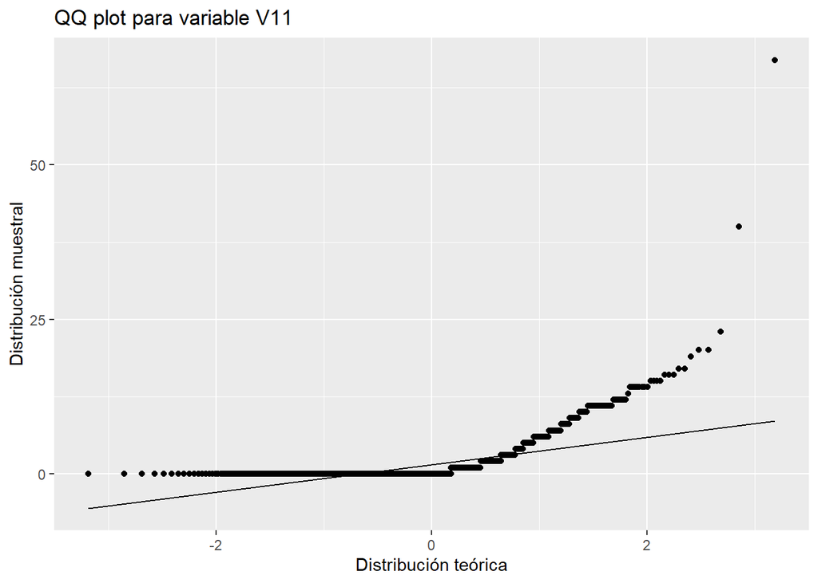

Los puntos se alinean con la línea teórica de la distribución normal en el rango medio, pero se desvían significativamente en los extremos. Esto indica que la distribución de V11 no sigue una normal estricta.

Los puntos que se alejan en el extremo derecho confirman un sesgo hacia valores positivos. Esto respalda lo que ya habíamos contemplado anteriormente.

Para detectar los valores fuera de rango utilizamos un diagrama de caja.

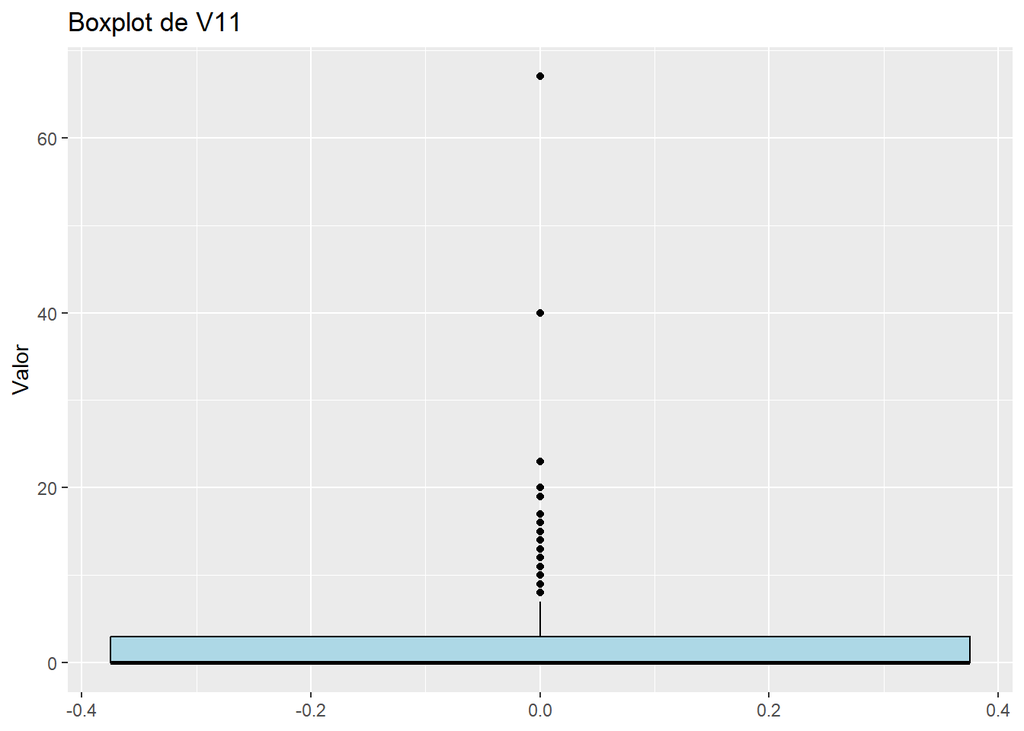

El boxplot muestra que los datos están fuertemente sesgados hacia valores más bajos, ya que la caja está muy comprimida cerca del eje inferior.

Hay varios outliers visibles como puntos dispersos por encima. Estos outliers son aquellos valores que se alejan significativamente del rango intercuartílico.

La presencia de muchos outliers y una mediana desplazada cerca de 0 sugiere que V11 no sigue una distribución normal, sino una asimetrica.

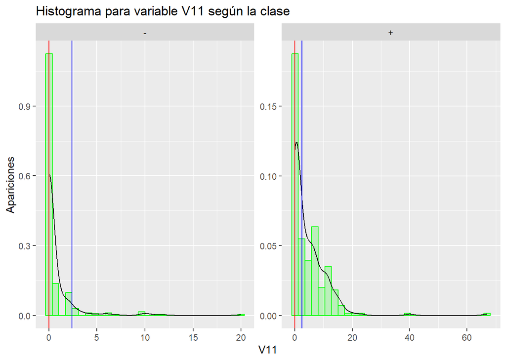

En este gráfico, vemos la distribución de la variable V11 separada por las clases.

Podemos observar que aunque ambas clases muestran distribuciones asimétricas y sesgadas hacia la derecha, la clase “+” parece tener una mayor variabilidad en los valores altos de V11, como lo indican las observaciones dispersas en rangos más amplios.

## V15

```r
V15 = credit$V15
summary(V15)
```

```
##     Min.  1st Qu.   Median     Mean  3rd Qu.     Max.
##      0.0      0.0      5.0   1017.4    395.5 100000.0
```

El primer cuartil es 0 y la mediana está muy cerca de 0, lo que indica que la mayoría de los valores de V15 son pequeños.

La media (1017.4) es mucho más alta que los cuartiles, lo que sugiere que existen valores extremadamente grandes (outliers) que están influyendo significativamente en la media.

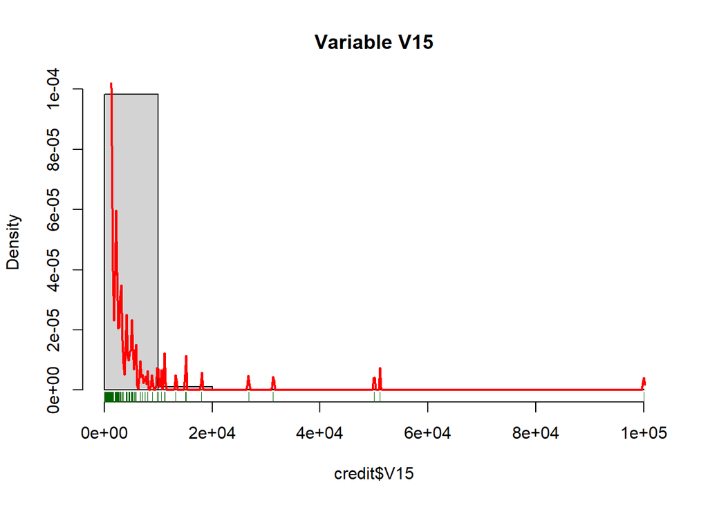

La densidad se concentra mayoritariamente en los valores cercanos a cero y la distribución está extremadamente sesgada a la derecha, con una larga cola hacia los valores altos.

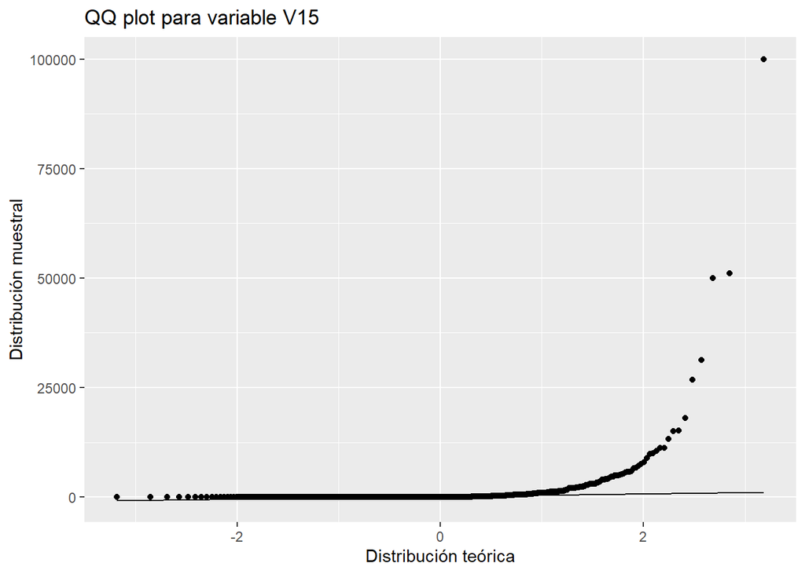

Los puntos del QQ plot muestran una fuerte desviación de la línea de normalidad, especialmente en los valores más altos, lo que confirma que la distribución de V15 no es normal. Los valores extremos en la cola derecha destacan como puntos alejados de la tendencia general (outliers significativos)

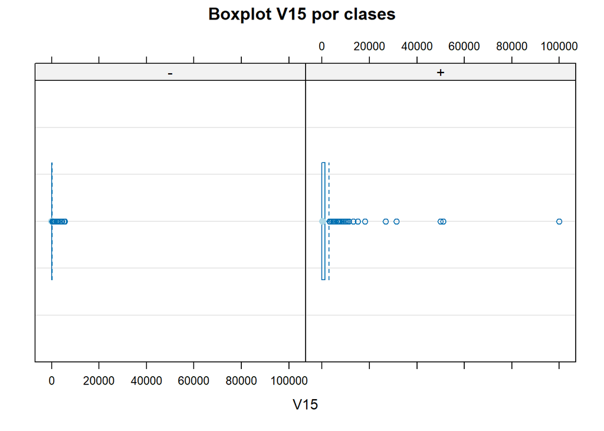

La clase (+) tiene más dispersión y valores altos en comparación a la clase negativa. Esto nos indica que V15 tiene una fuerte relación con la variable de clase V16, por lo tanto sea un predictor de gran fuerza y los outliers sean necesarios y no debamos eliminarlos.

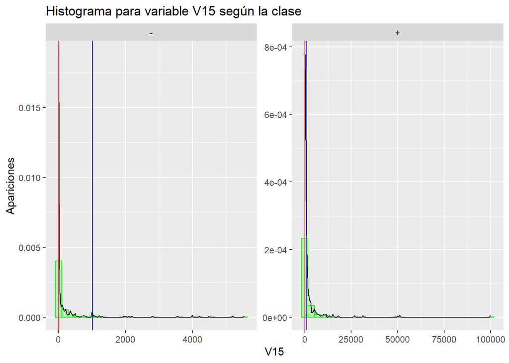

Aunque ambas clases comparten la tendencia de acumulación de valores bajos, la clase + parece tener una distribución más dispersa, con un mayor número de valores altos. Esto sugiere que V15 podría ser un indicador relevante para diferenciar entre las clases como ya observabamos anteriormente.